# PEAR - Biodiversidade & Ecossistemas

Author

Felipe Melo

# Respositório github para estas análises

[AQUI](https://github.com/fplmelo/pear)

## Carregar dados e blibliotecas

## Carregando bases espaciais dos municípios de PE

Usamos o pacote `geobr` para contruir os mapas que serão usados para ilustrar os resultados espaccialmente.

### Gráfico teste

Um gráfico teste para unir os municípios de PE e os registros de espécies compilados no GBIF. Esses dados serão posteriormente usados para interpretar o risco à biodiversidade e ecossistemas e separar zonas mais ou menos amostradas quanto à biodiversidade.

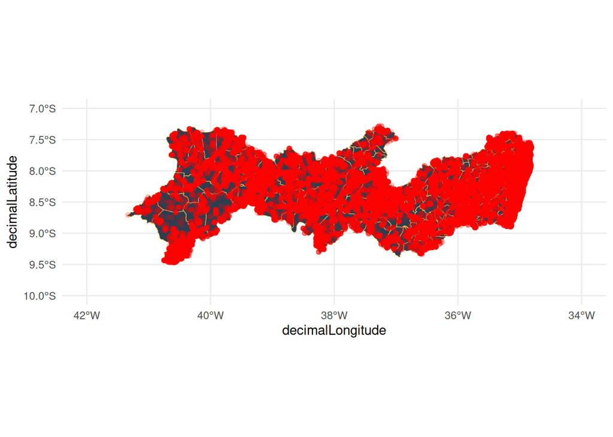

## Dados descritivos para biodiversidade

```
Simple feature collection with 5 features and 2 fields
Geometry type: MULTIPOINT
Dimension:     XY
Bounding box:  xmin: -41.33322 ymin: -9.474889 xmax: -32.38081 ymax: -3.807668
Geodetic CRS:  SIRGAS 2000
# A tibble: 5 × 3
  kingdom    `n()`                                                      geometry
  <chr>      <int>                                              <MULTIPOINT [°]>
1 Animalia  186485 ((-32.40694 -3.854444), (-32.40705 -3.855881), (-32.40805 -3…
2 Bacteria      32 ((-36.48306 -8.949722), (-37.45 -8.599722), (-38.5 -8), (-37…
3 Chromista     87 ((-32.40111 -3.856667), (-32.41056 -3.840278), (-32.41528 -3…
4 Fungi       4406 ((-32.42379 -3.853808), (-32.42556 -3.865992), (-32.42594 -3…
5 Plantae    71322 ((-32.40028 -3.856944), (-32.40111 -3.856667), (-32.40139 -3…
```

```
Simple feature collection with 57 features and 3 fields
Geometry type: MULTIPOLYGON
Dimension:     XY
Bounding box:  xmin: -40.86179 ymin: -9.225121 xmax: -35.03658 ymax: -7.27416
Geodetic CRS:  SIRGAS 2000
# A tibble: 57 × 4
   name_muni              sp_per_area     n                             geometry
   <chr>                        <dbl> <int>                   <MULTIPOLYGON [°]>
 1 Santa Maria do Cambucá      0.0324     3 (((-35.89174 -7.779958, -35.8935 -7…
 2 Tuparetama                  0.0158     3 (((-37.24368 -7.729325, -37.24065 -…
 3 Ibirajuba                   0.0210     4 (((-36.11584 -8.5784, -36.13687 -8.…
 4 Machados                    0.0646     4 (((-35.47499 -7.677582, -35.51584 -…
 5 Salgadinho                  0.0457     4 (((-35.628 -7.942101, -35.62775 -7.…
 6 Solidão                     0.0288     4 (((-37.62439 -7.63224, -37.62418 -7…
 7 Casinhas                    0.0430     5 (((-35.70937 -7.817412, -35.71065 -…
 8 Condado                     0.0555     5 (((-35.06982 -7.58144, -35.06901 -7…
 9 Frei Miguelinho             0.0234     5 (((-35.83614 -7.982886, -35.83342 -…
10 Calçado                     0.0490     6 (((-36.33826 -8.787042, -36.32878 -…
# ℹ 47 more rows
```

```
Simple feature collection with 184 features and 2 fields
Geometry type: MULTIPOLYGON
Dimension:     XY
Bounding box:  xmin: -41.35834 ymin: -9.482897 xmax: -34.80669 ymax: -7.272954
Geodetic CRS:  SIRGAS 2000
# A tibble: 184 × 3
   name_muni              sp_per_area                                   geometry
   <chr>                        <dbl>                         <MULTIPOLYGON [°]>
 1 Tuparetama                  0.0158 (((-37.24368 -7.729325, -37.24065 -7.7357…
 2 Capoeiras                   0.0177 (((-36.59868 -8.769434, -36.59727 -8.7699…
 3 Ibirajuba                   0.0210 (((-36.11584 -8.5784, -36.13687 -8.565513…
 4 Frei Miguelinho             0.0234 (((-35.83614 -7.982886, -35.83342 -7.9825…
 5 Solidão                     0.0288 (((-37.62439 -7.63224, -37.62418 -7.63204…
 6 Santa Maria do Cambucá      0.0324 (((-35.89174 -7.779958, -35.8935 -7.78367…
 7 Santa Terezinha             0.0348 (((-37.50034 -7.408593, -37.50135 -7.4114…
 8 Casinhas                    0.0430 (((-35.70937 -7.817412, -35.71065 -7.8174…
 9 Salgadinho                  0.0457 (((-35.628 -7.942101, -35.62775 -7.942909…
10 Carnaíba                    0.0489 (((-37.74316 -7.877418, -37.73124 -7.902,…
# ℹ 174 more rows
```

## Esforço de coleta por RDS de PE

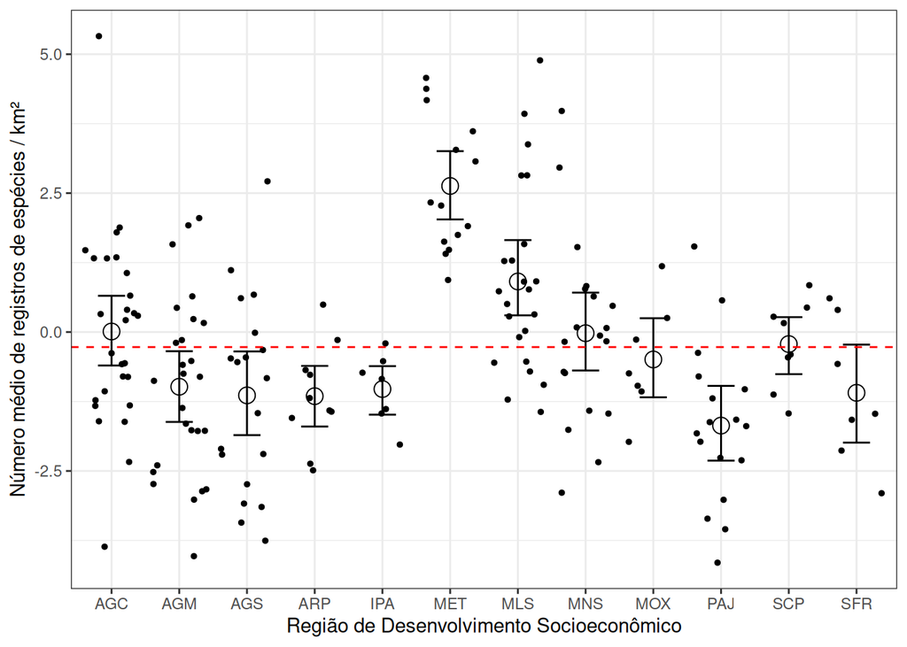

## Dados de registros de espécies por município (fonte: GBIF)

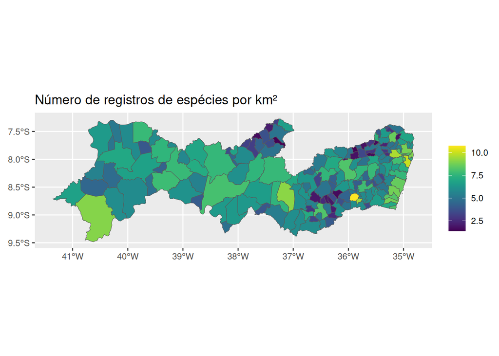

# Análise de risco climático para área temática de Biodievrsidade e Ecossistemas

Dados provenientes do Adapta Brasil

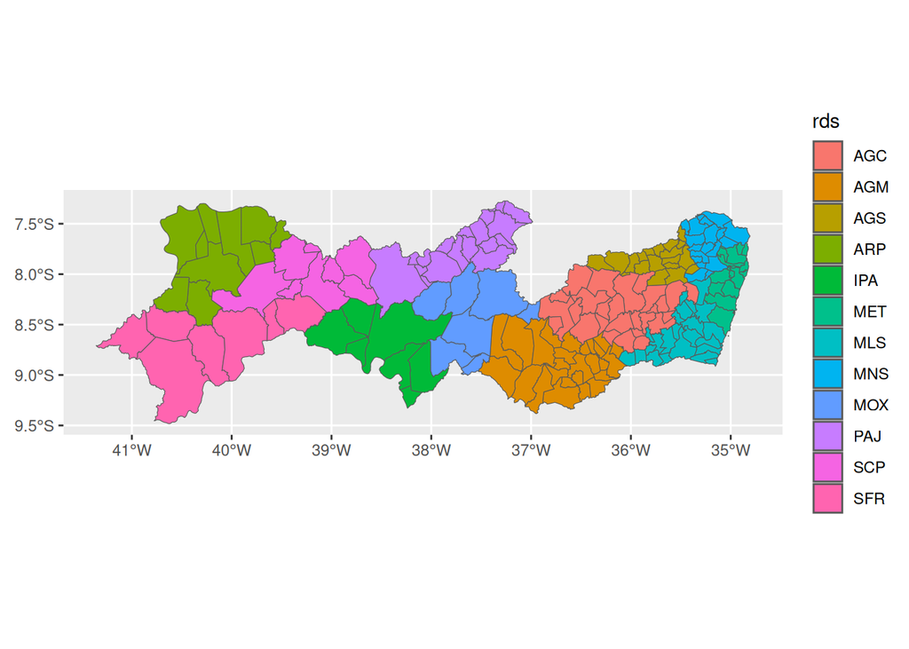

## Análise de Vulnerabilidade

Grau de suscetibilidade do bioma a uma determinada ameaça climática. A vulnerabilidade refere-se às características que um determinado ecossistema possui que refletem à **suscetibilidade** dele em relação às variações climáticas que podem afetar, direta ou indiretamente, a integridade do bioma. A vulnerabilidade está vinculada a situação de **sensibilidade** e **capacidade adaptativa** desse sistema, ou seja, se baseia em fatores conjunturais existentes antes do impacto climático. (fonte: AdaptaBrasil)

# Sensibilidade do bioma

Grau de alteração potencial do estado que o ecossistema pode sofrer, direta ou indiretamente, uma vez em contato com as variações climáticas que afetam a integridade do bioma. A sensibilidade é uma propriedade inerente a um ecossistema, existente antes da ameaça climática e independente (separada) da exposição. O Índice de Sensibilidade é composto pelos indicadores temáticos: **Mudança e uso do solo, Cobertura do solo, Densidade populacional e de estabelecimentos, e Infraestrutura**.

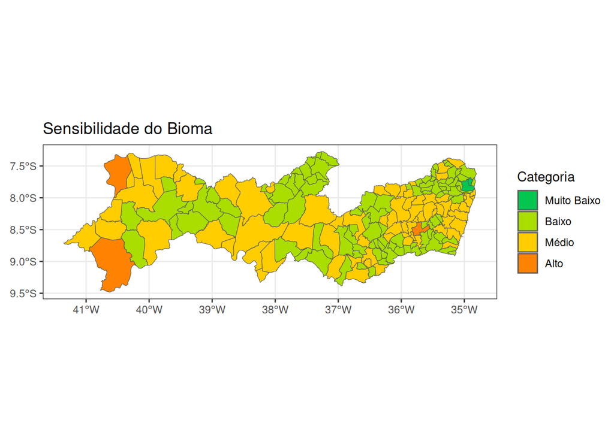

```
Importance of components:
                          PC1    PC2    PC3    PC4
Standard deviation     1.2739 0.9933 0.8990 0.7632
Proportion of Variance 0.4057 0.2467 0.2020 0.1456
Cumulative Proportion  0.4057 0.6524 0.8544 1.0000
```

```
                      PC1          PC2         PC3        PC4
s_luc_2017     -0.5512354  0.084998041 -0.66077759 -0.5022826
s_csol_2017    -0.2310101 -0.933404921  0.20847285 -0.1786859
s_dens_pop_faz  0.6329621  0.004354507  0.05927837 -0.7718977
s_infra_2017   -0.4920700  0.348585177  0.71860846 -0.3463487
```

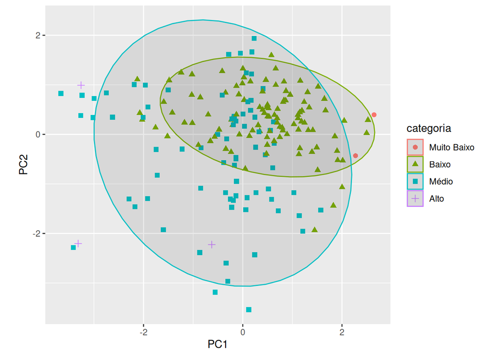

#### Resumo da análise de sensibilidade

Os componentes da sensibilidade são praticamente ortogonais, significando que qualquer redução na dimensionalidade é prejudicial à interpretação. O primeiro PC é o úico com valor > 1 mas os PCs 2 e 3 tem valores muito próximos de 1. Portanto, o melhor é proceder para uma análise dos componentes do índice de sensibilidade de forma separada e isolada.

## Sensibilidade do bioma

Daqui por diante as análises virão com duas representações gráficoas: 1) mapa de de PE com valores por município, podendo ser valores brutos ou categóricos (categorias Adapta Brasil) e 2) Gráfico mostrando valores médios e variação por região de desenvolvimento socioeconômico (RDS).

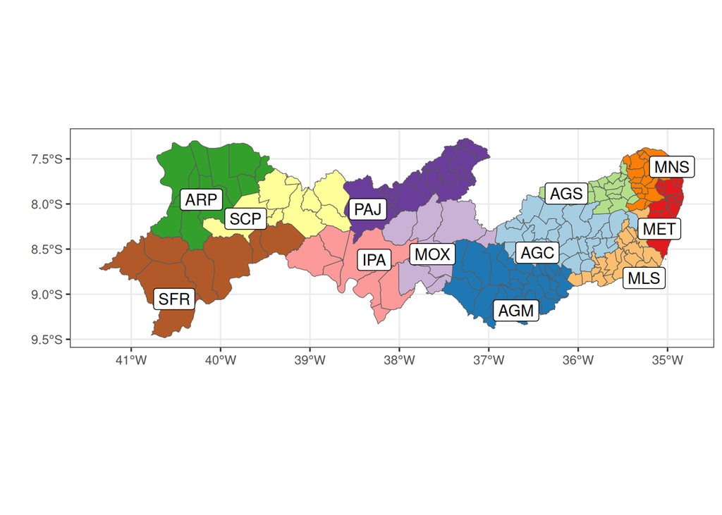

Essas são as RDs de Pernambuco

### Indicador temático - Mudança e uso do solo

Indicador composto por 4 variáveis: 1-Uso de Agrotóxicos; 2- Estabelecimentos com agricultura familiar; 3- Estabalecimentos com práticas sustentáveis e 4- Frequência de focos do fogo

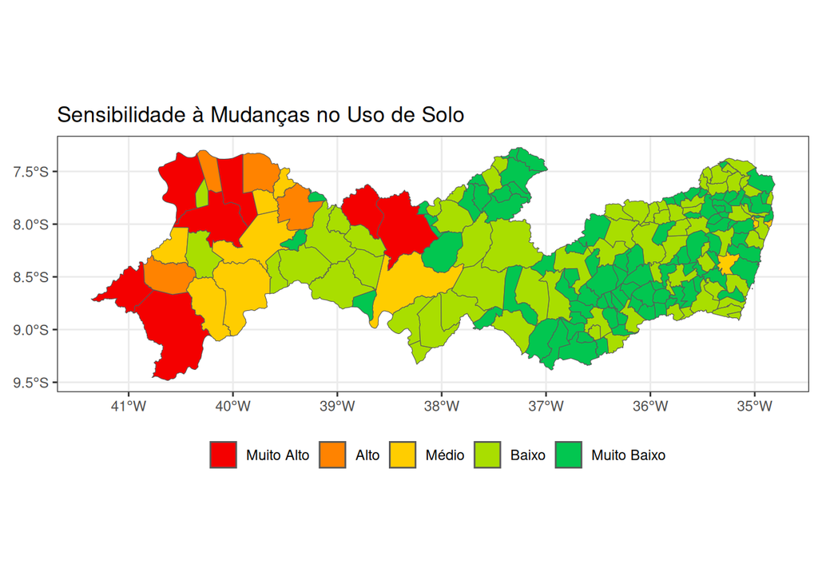

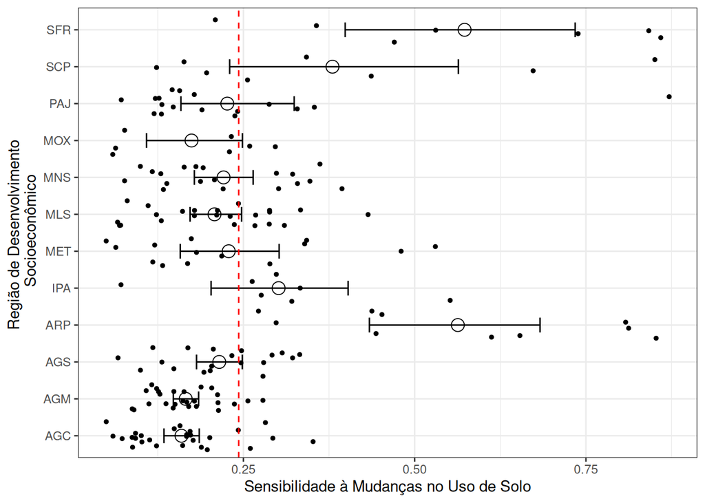

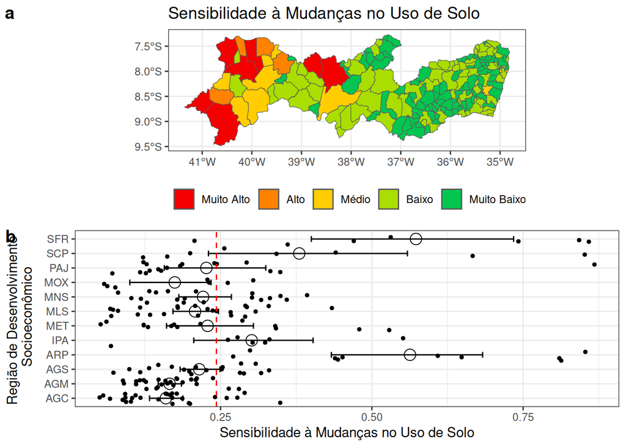

**Conclusão**: Há um gradiente de sensibiliadde á mudança no uso de solo que aumenta em direção ao oeste, particularmente nas RD de SFR e ARP (valores acima da média para o estado). Por outro lado, as RD de AGM e AGC e AGM (Agreste), possuem menor vulnerabilidade a essas mudanças.

### Indicadores individuais - Mudança e uso do solo

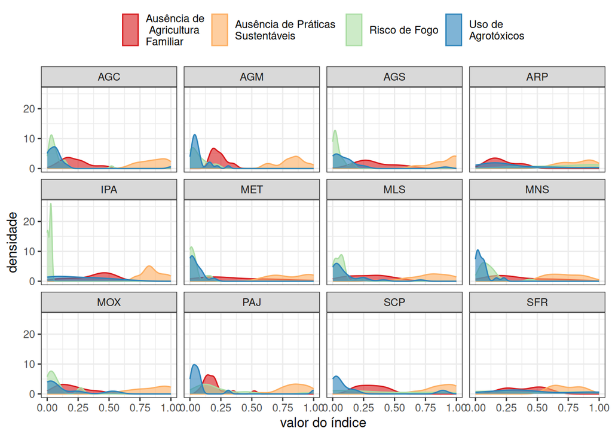

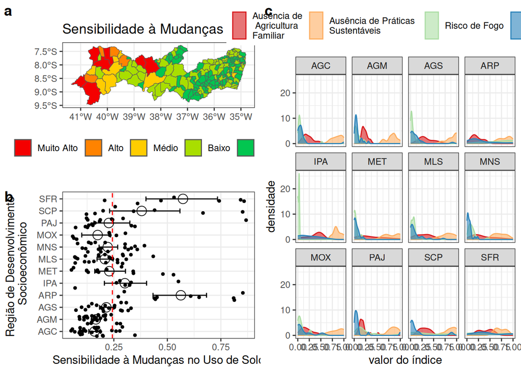

**Conclusão**: Com base nos indicadores individuais de **Mudança e Uso de Solo** é possível perceber que praticamente todos os municípios e RDs de PE não possuem práticas sustentáveis de agricultura, obtendo valores altos de sensibilidade e gerandobaixa distintção entre entidades (município ou RD). As RD do Agreste têm baixo uso de agrotóxico e baixo risco de fogo. Os altos valores de sensibilidade a mudança e uso de solo estão concentrados nas RDs de SFR, SCP e ARP, onde há municípios com maior sensisbilidade à todos os indicadores individuais.

### Indicador temático - Cobertura do solo

Indicador composto por 4 variáveis: 1-Passivo ambiental; 2- Desmatamento; 3- Pastagem degradada e 4- Mineração

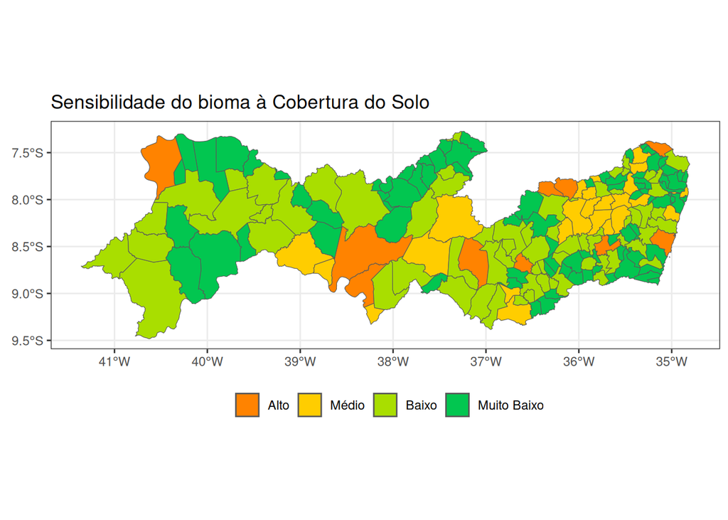

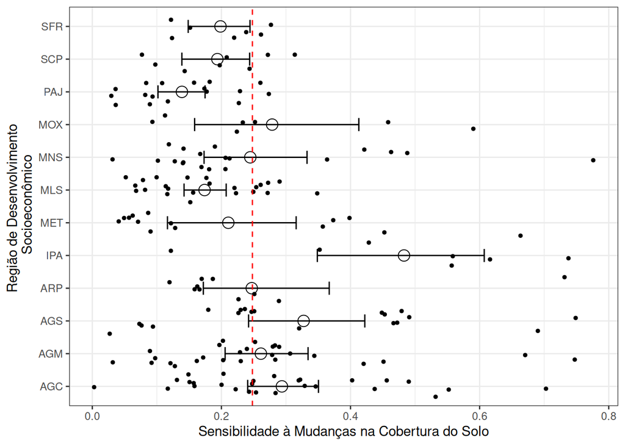

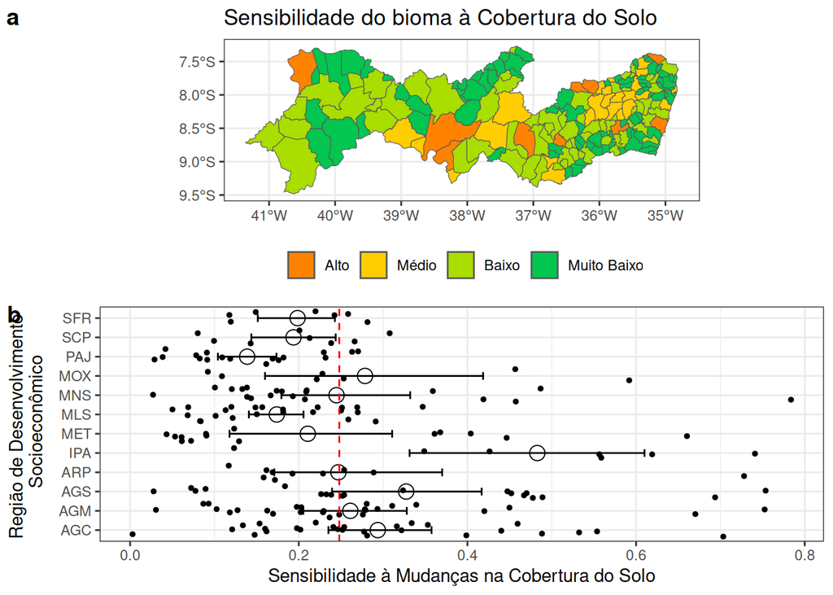

**Conclusão**: Não há um padrão muito claro espacial para este indicador, com exceção de alguns núcleos de alta sensibilidade espalhados pelo estado e outros de média sensibilidade. Destaque para o IPA.

### Indicadores individuais - Cobertura do solo

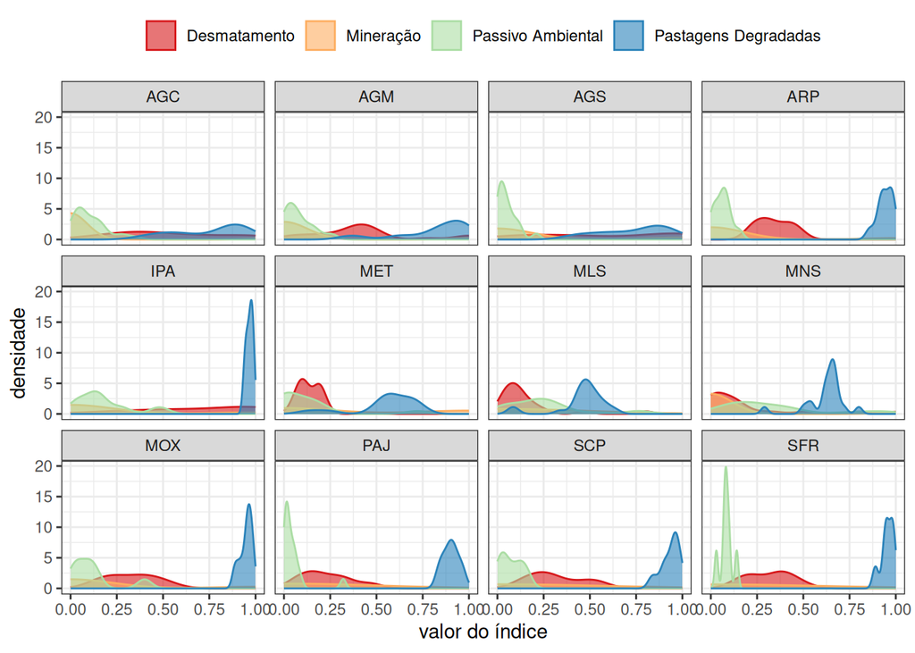

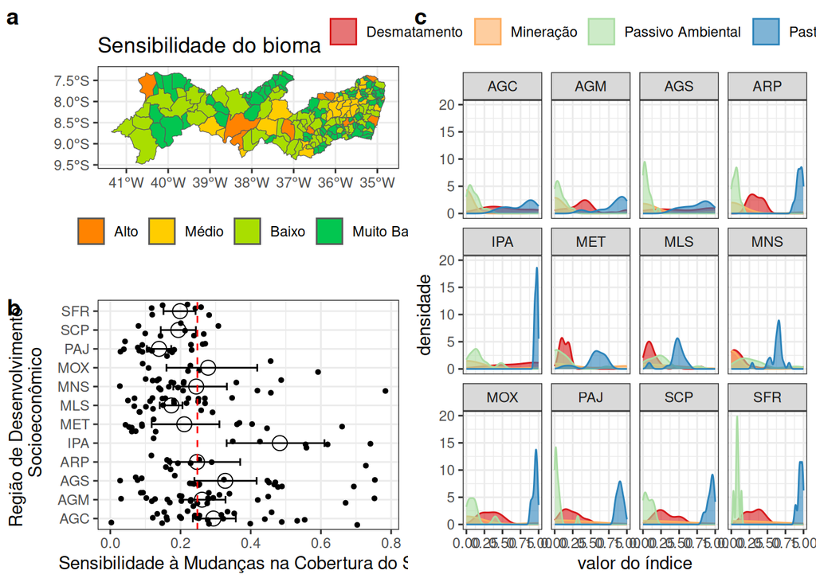

**Conclusão**: Com base nos indicadores individuais de **Cobertura do Solo** podemos verificar que praticamente toda a zona seca do estado possui pastagens degradadas. Por outro lado, o passivo ambiental é geralmente baixo, sugerindo que a maior parte dos municípios possui RL e APP conservadas (Será?). O que mais diferencia os municípios é o desmatamento, que se espalha fortemente pelo Agreste Central e Meridional (AGC e AGM) elaguns municípios do Sertão.

### Indicador temático - Densidade populacional e de estabelecimentos

Indicador composto por 2 variáveis: 1-População humana; 2- Densidade de estabelecimentos agropecuária

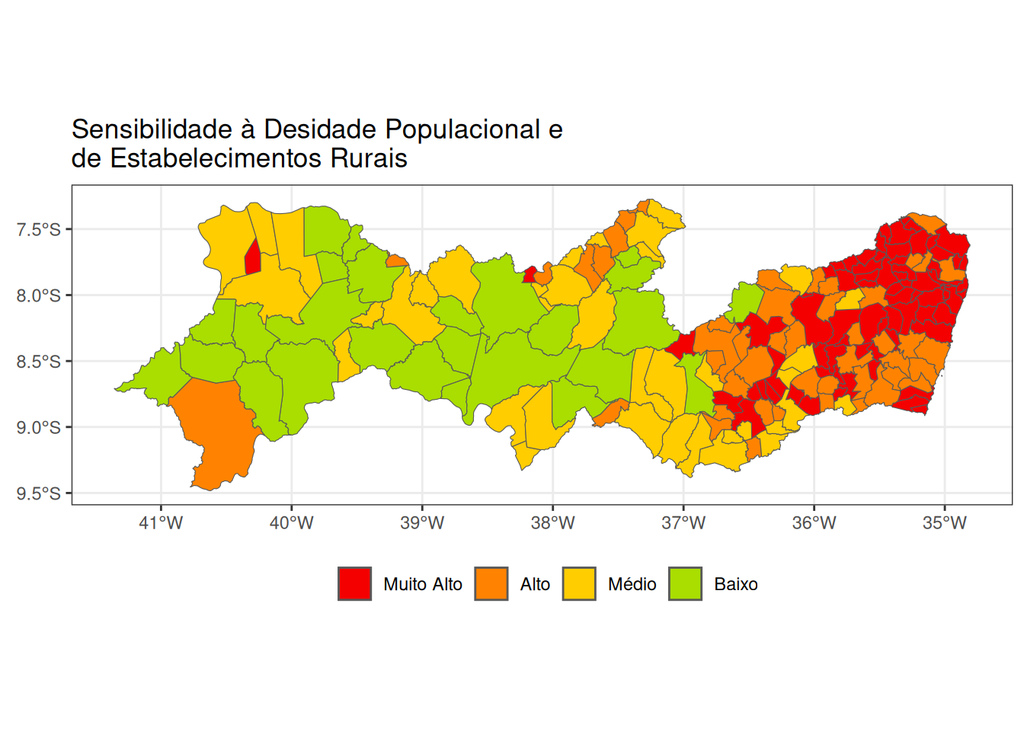

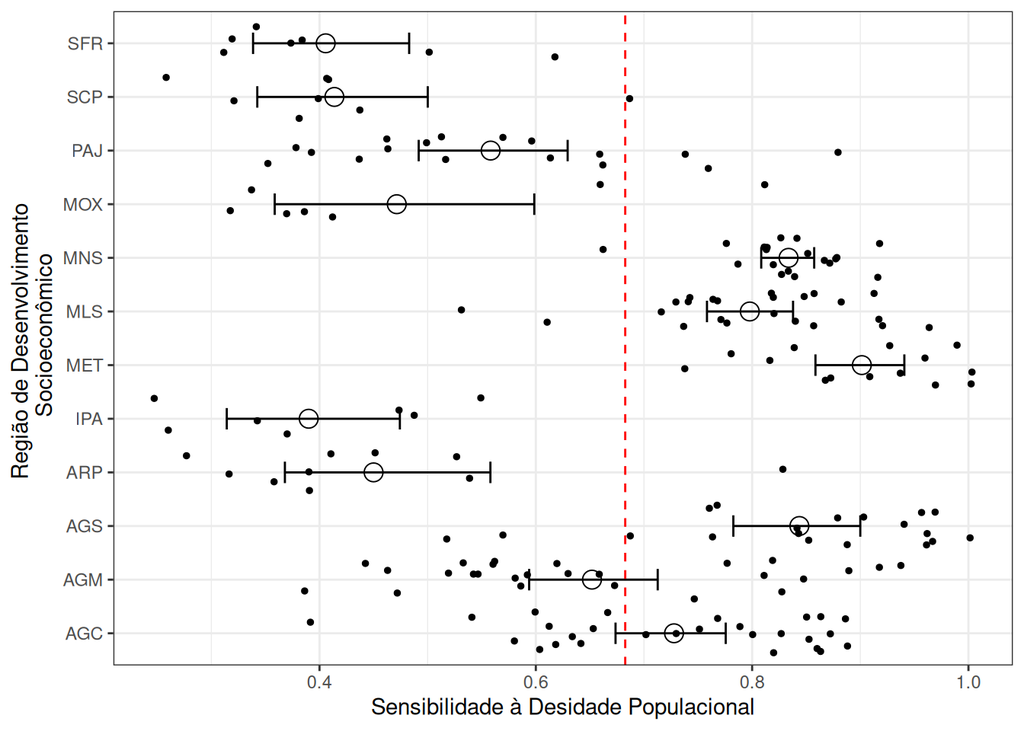

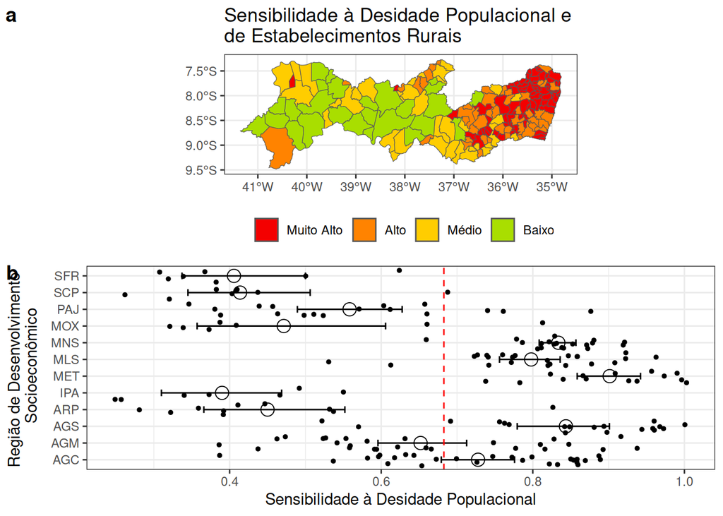

### Indicadores individuais - Densidade Populacional

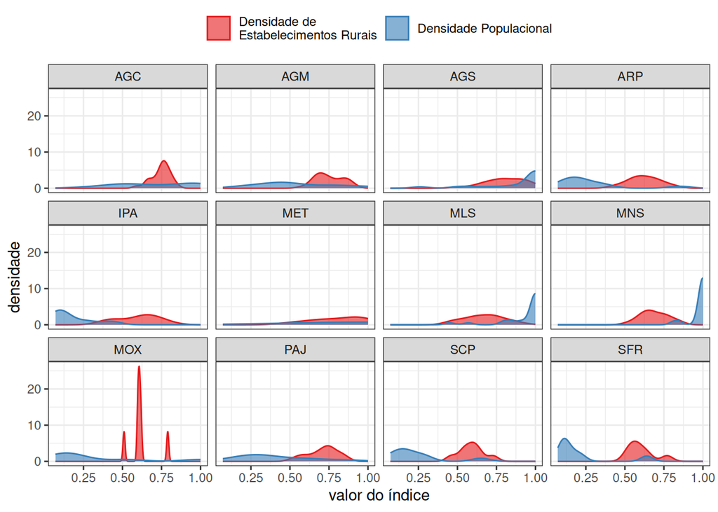

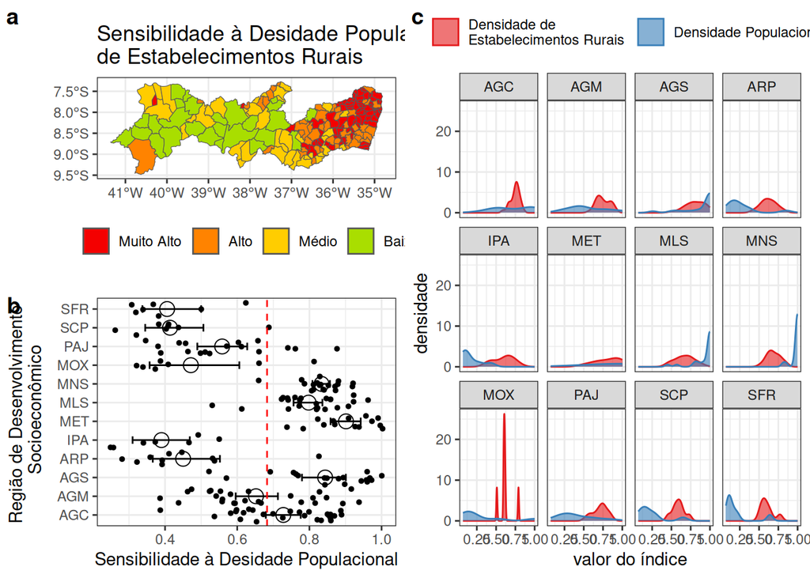

### Indicador temático - Infraestrutura

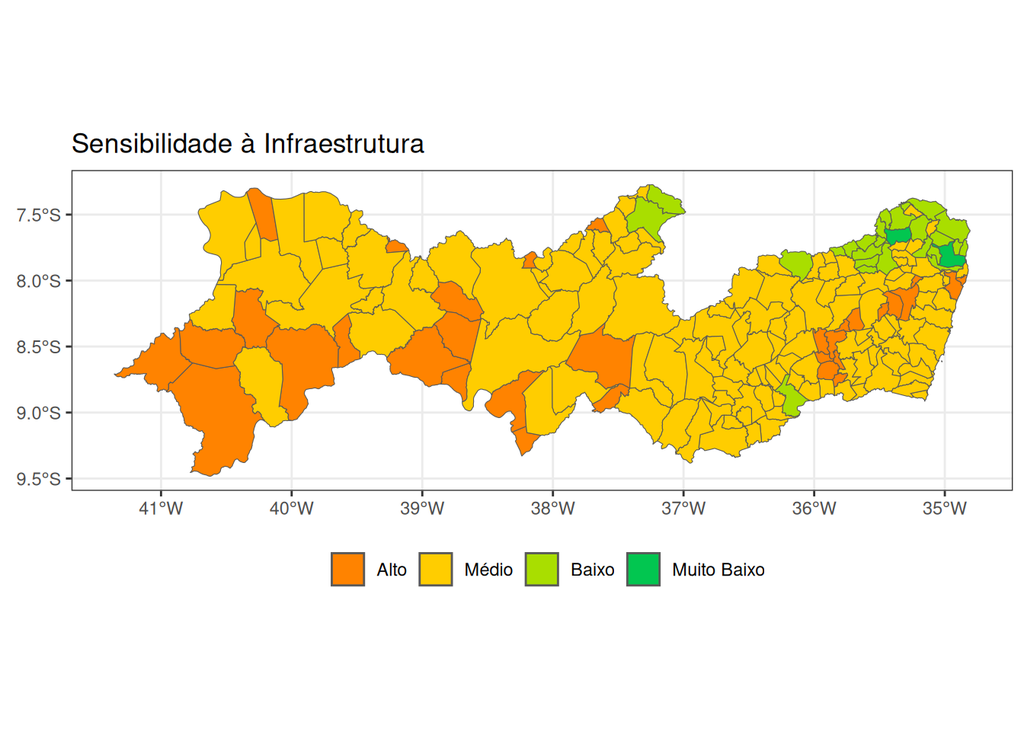

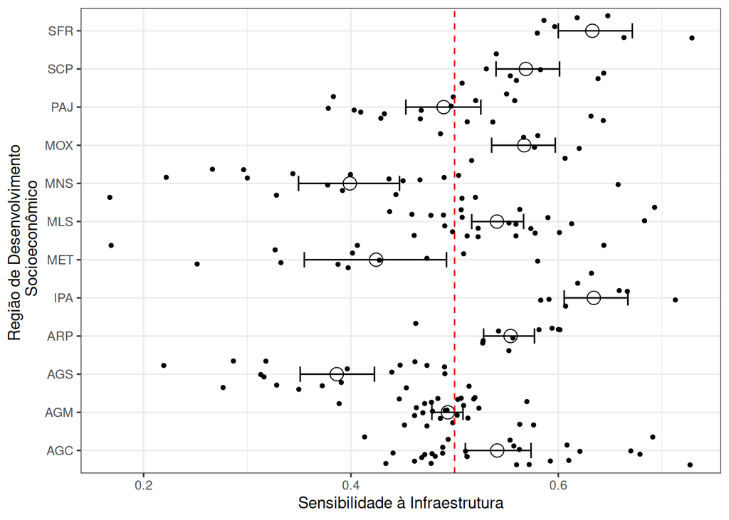

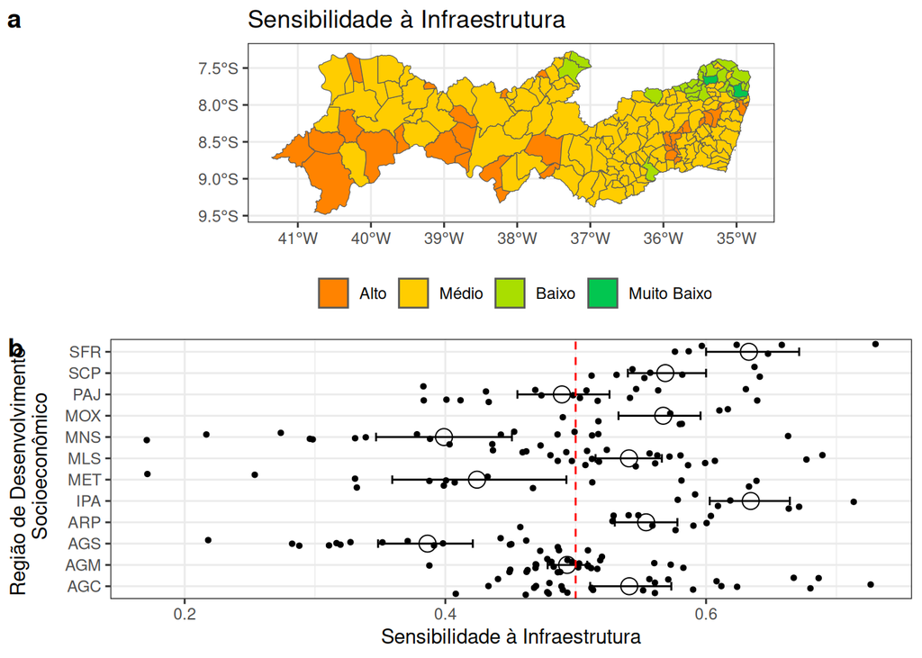

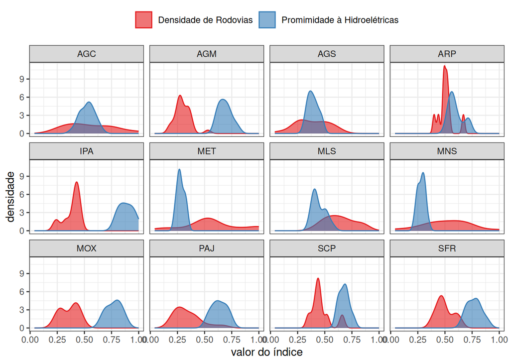

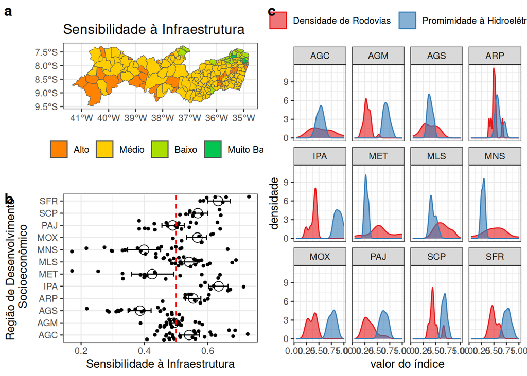

# Capacidade Adaptativa

Capacidade do ecossistema de se preparar e se ajustar às alterações climáticas ou aos danos climáticos potenciais para a integridade do bioma, principalmente para diminuir os impactos negativos, aproveitar as oportunidades ou responder às consequências. O Índice de Capacidade Adaptativa é composto pelo indicador temático: Instrumentos para conservação da biodiversidade.

Indicador composto por 2 variáveis: 1- Orientação para UC e 2 - UCs

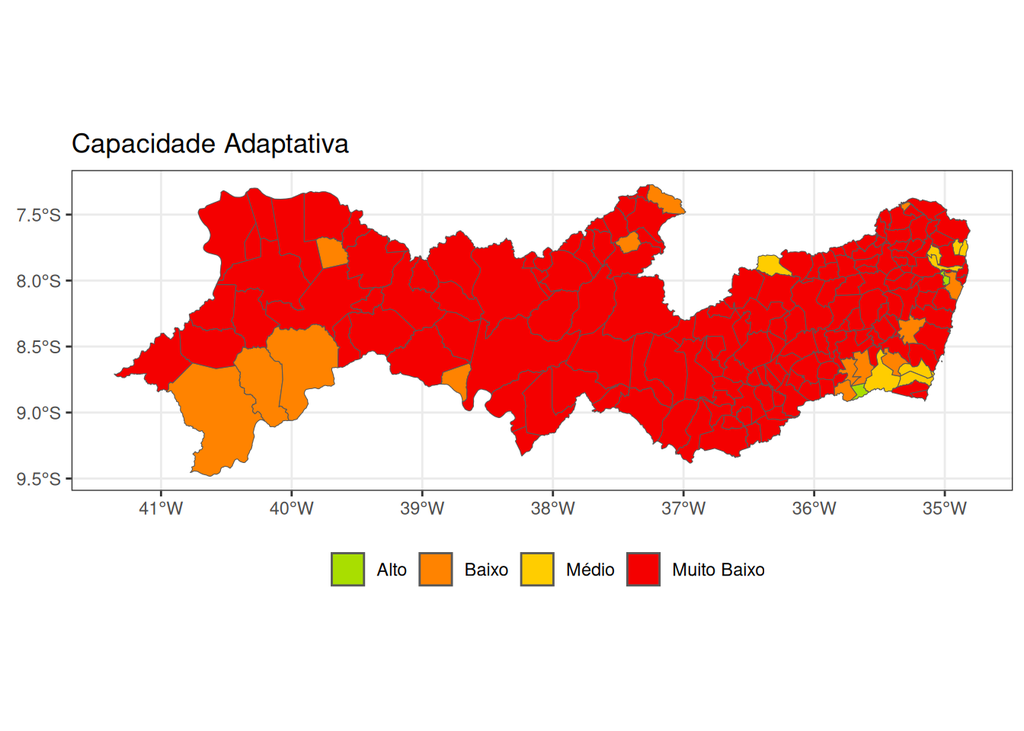

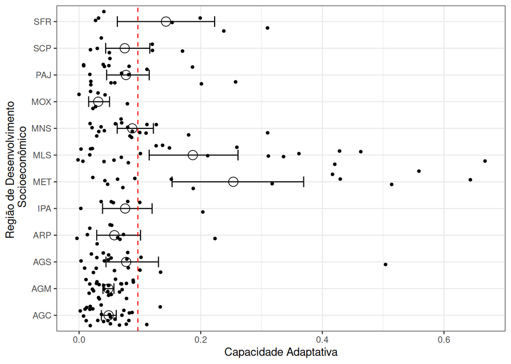

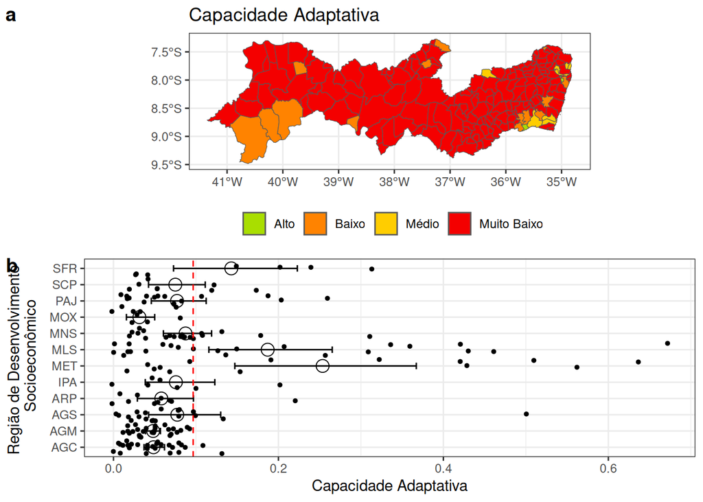

**Conclusão**: Poucas UCs e de baixa implementação (falta de comitê gestor) não ajudam na capacidade adaptativa dos bioma frente às mudanças climáticas.

### Indicadores individuais - Capacidade Adaptativa

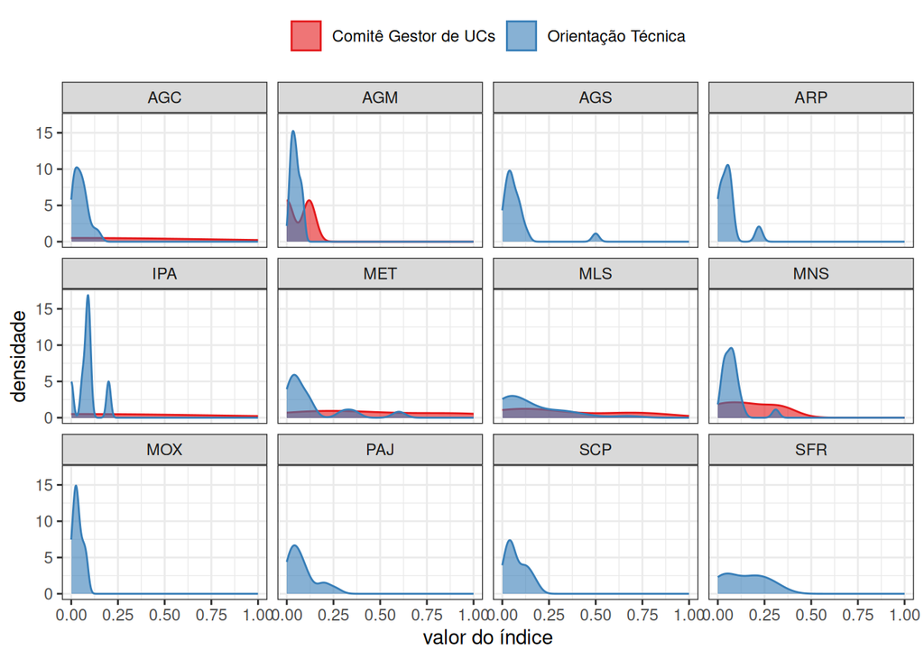

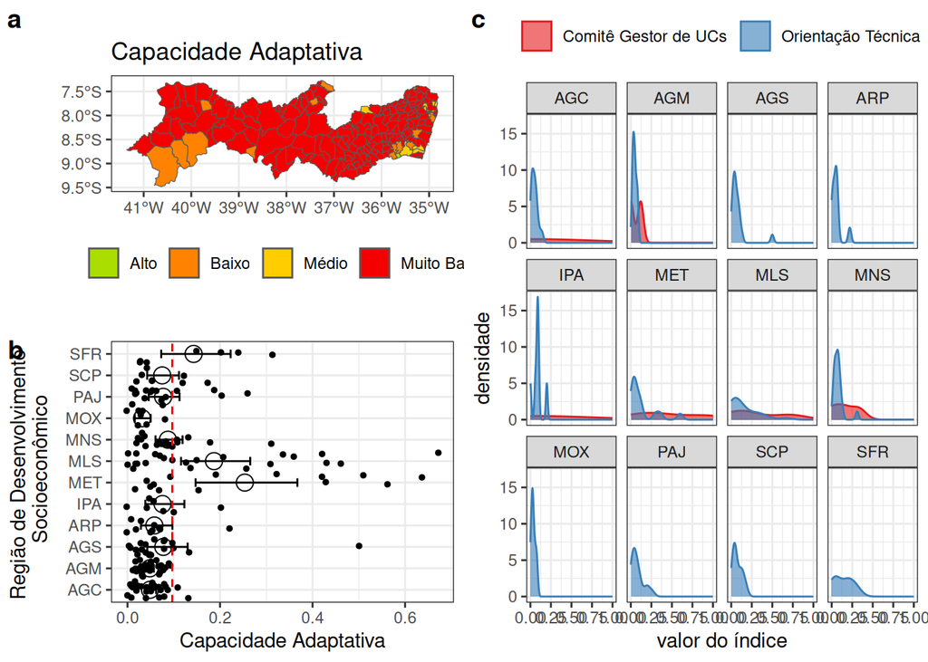